# IV（2SLS）估计应用R实现

xuefliang

August 19, 2017

[output not shown]

数据：grilic.dta 变量：lw（工资对数），s（受教育年限），age（年龄），exper（工作经验），tenure（在单位的工作年数）、IQ（智商），mrt（母亲的受教育年限），kww（在“knowledge of the World of Work”测试中的成绩），mrt（婚姻虚拟变量，已婚=1），rns（美国南方虚拟变量，住在南方=1），smsa（大城市虚拟变量，住在大城市=1）

IV估计的步骤： （一）做普通最小二乘法OLS估计，看看是否存在回归结果的不可靠性，然后初始怀疑存在内生性问题。具体细分两步： 打开数据文件,简单描述性统计分析,简单双变量相关分析，Pearson相关分析，怀疑遗漏变量iq，考察智商与受教育年限的相关关系

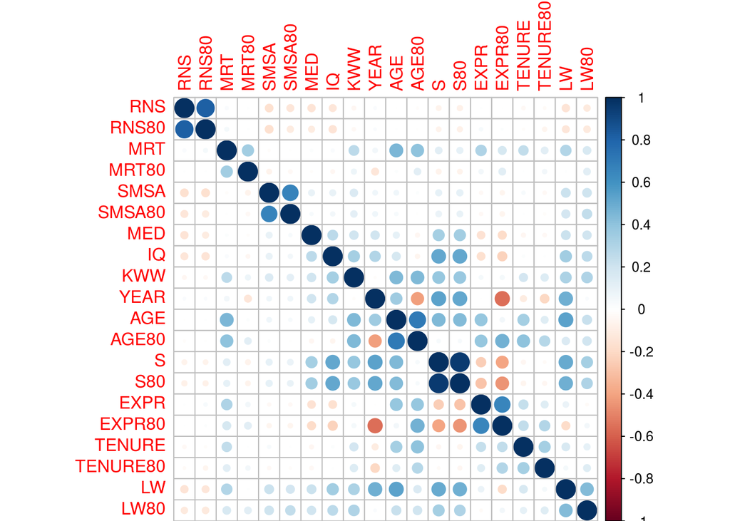

```r
grilic <- read_excel("./grilic.xls")
corrplot(cor(grilic), method = "circle")
```

```r
cor.test(grilic$IQ,grilic$S)
```

```
##
##  Pearson's product-moment correlation
##
## data:  grilic$IQ and grilic$S
## t = 16.437, df = 756, p-value < 2.2e-16
## alternative hypothesis: true correlation is not equal to 0
## 95 percent confidence interval:
##  0.4586671 0.5637292
## sample estimates:
##       cor
## 0.5131176
```

```r
fit.lm1 <- lm(LW~S+EXPR+TENURE+RNS+SMSA,data = grilic)
summary(fit.lm1)
```

```
##
## Call:
## lm(formula = LW ~ S + EXPR + TENURE + RNS + SMSA, data = grilic)
##
## Residuals:
##      Min       1Q   Median       3Q      Max
## -1.11684 -0.22626 -0.01511  0.23103  1.23738
##
## Coefficients:
##              Estimate Std. Error t value Pr(>|t|)
## (Intercept)  4.103675   0.085097  48.223  < 2e-16 ***
## S            0.102643   0.005849  17.549  < 2e-16 ***
## EXPR         0.038119   0.006327   6.025 2.65e-09 ***
## TENURE       0.035615   0.007742   4.600 4.96e-06 ***
## RNS         -0.084080   0.028797  -2.920  0.00361 **
## SMSA         0.139667   0.028082   4.974 8.15e-07 ***
## ---
## Signif. codes:  0 '***' 0.001 '**' 0.01 '*' 0.05 '.' 0.1 ' ' 1
##
## Residual standard error: 0.3464 on 752 degrees of freedom
## Multiple R-squared:  0.3521, Adjusted R-squared:  0.3478
## F-statistic: 81.75 on 5 and 752 DF,  p-value: < 2.2e-16
```

回归结果显示，教育投资的年回报率为10.26%，而且在1%的水平上显著的不为零。这意味着，多受一年教育，则未来的工资将高出10.26%，这个教育投资回报率似乎太高了。可能的原因，由于遗漏变量“能力”与受教育年限正相关，故“能力”对工资的贡献也被纳入教育的贡献，因此高估了教育的回报率。

2、引入所怀疑的内生变量在进行OLS回归。 引入智商IQ作为“能力”的代理变量，再进行OLS回归。

```r
fit.lm2 <- lm(LW~S+IQ+EXPR+TENURE+RNS+SMSA,data = grilic)
summary(fit.lm2)
```

```
##
## Call:
## lm(formula = LW ~ S + IQ + EXPR + TENURE + RNS + SMSA, data = grilic)
##
## Residuals:
##      Min       1Q   Median       3Q      Max
## -1.16056 -0.21786 -0.00621  0.22771  1.20580
##
## Coefficients:
##              Estimate Std. Error t value Pr(>|t|)
## (Intercept)  3.895172   0.109110  35.699  < 2e-16 ***
## S            0.092787   0.006666  13.920  < 2e-16 ***
## IQ           0.003279   0.001083   3.028  0.00255 **
## EXPR         0.039344   0.006306   6.239 7.33e-10 ***
## TENURE       0.034209   0.007715   4.434 1.06e-05 ***
## RNS         -0.074532   0.028815  -2.587  0.00988 **
## SMSA         0.136737   0.027948   4.893 1.22e-06 ***
## ---
## Signif. codes:  0 '***' 0.001 '**' 0.01 '*' 0.05 '.' 0.1 ' ' 1
##
## Residual standard error: 0.3445 on 751 degrees of freedom
## Multiple R-squared:   0.36,  Adjusted R-squared:  0.3548
## F-statistic: 70.39 on 6 and 751 DF,  p-value: < 2.2e-16
```

加入“能力”的代理变量IQ后，教育投资的回报率下降为9.28%，变得更为合理些，但仍然显得过高。

（二）选择工具变量，一般源于以往文献中相应与内生变量有关、但未引入研究的方程里的变量。具体细分为两步： 1、初始工具变量的检测 由于IQ来度量能力存在“测量误差”，故IQ是内生变量，考虑使用变量（med,kww,mrt,age)作为IQ的工具变量，进行2SLS回归，并使用稳健标准误差。

```r
iv1 = ivreg(LW~IQ+S+EXPR+TENURE+RNS+SMSA | S+EXPR+TENURE+RNS+SMSA+MED+KWW+MRT+AGE,data = grilic)
summary(iv1, vcov = sandwich, diagnostics = TRUE)
```

```
##
## Call:
## ivreg(formula = LW ~ IQ + S + EXPR + TENURE + RNS + SMSA | S +
##     EXPR + TENURE + RNS + SMSA + MED + KWW + MRT + AGE, data = grilic)
##
## Residuals:
##        Min         1Q     Median         3Q        Max
## -1.3825406 -0.2437078  0.0009735  0.2514623  1.4609417
##
## Coefficients:
##              Estimate Std. Error t value Pr(>|t|)
## (Intercept)  4.837875   0.379943  12.733  < 2e-16 ***
## IQ          -0.011547   0.005638  -2.048  0.04089 *
## S            0.137348   0.017499   7.849 1.45e-14 ***
## EXPR         0.033804   0.007484   4.517 7.29e-06 ***
## TENURE       0.040564   0.009585   4.232 2.60e-05 ***
## RNS         -0.117698   0.035958  -3.273  0.00111 **
## SMSA         0.149983   0.032228   4.654 3.85e-06 ***
##
## Diagnostic tests:
##                  df1 df2 statistic  p-value
## Weak instruments   4 748     9.713 1.16e-07 ***
## Wu-Hausman         1 750     9.568  0.00205 **
## Sargan             3  NA    61.137 3.36e-13 ***
## ---
## Signif. codes:  0 '***' 0.001 '**' 0.01 '*' 0.05 '.' 0.1 ' ' 1
##
## Residual standard error: 0.3851 on 751 degrees of freedom
## Multiple R-Squared: 0.2002,  Adjusted R-squared: 0.1938
## Wald test: 59.29 on 6 and 751 DF,  p-value: < 2.2e-16
```

```r
iv2 = ivreg(LW~IQ+S+EXPR+TENURE+RNS+SMSA | S+EXPR+TENURE+RNS+SMSA+MED+KWW,data = grilic)
summary(iv2, vcov = sandwich, diagnostics = TRUE)
```

```
##
## Call:
## ivreg(formula = LW ~ IQ + S + EXPR + TENURE + RNS + SMSA | S +
##     EXPR + TENURE + RNS + SMSA + MED + KWW, data = grilic)
##
## Residuals:
##        Min         1Q     Median         3Q        Max
## -1.3025532 -0.2405657  0.0005968  0.2349961  1.2621666
##
## Coefficients:
##              Estimate Std. Error t value Pr(>|t|)
## (Intercept)  3.218043   0.398368   8.078 2.62e-15 ***
## IQ           0.013928   0.006039   2.306 0.021366 *
## S            0.060780   0.018951   3.207 0.001397 **
## EXPR         0.043324   0.007412   5.845 7.54e-09 ***
## TENURE       0.029644   0.008317   3.564 0.000388 ***
## RNS         -0.043527   0.034478  -1.262 0.207173
## SMSA         0.127222   0.029741   4.278 2.13e-05 ***
##
## Diagnostic tests:
##                  df1 df2 statistic  p-value
## Weak instruments   2 750    13.546 1.66e-06 ***
## Wu-Hausman         1 750     3.695    0.055 .
## Sargan             1  NA     0.130    0.718
## ---
## Signif. codes:  0 '***' 0.001 '**' 0.01 '*' 0.05 '.' 0.1 ' ' 1
##
## Residual standard error: 0.3661 on 751 degrees of freedom
## Multiple R-Squared: 0.2775,  Adjusted R-squared: 0.2718
## Wald test: 61.67 on 6 and 751 DF,  p-value: < 2.2e-16
```

结果显示，教育投资回报率降为6.08%，比较合理；而且IQ的贡献也重新变为正。继续做过度识别检验。 estat overid 接受原假设，认为（med,kww）外生。

（三）考察工具的相关性，即弱工具变量判断（Stock and Yogo, 2005），使用拇指法则（Rule of Thumb，又叫“经验法则”，是一种可用于许多情况的简单的，经验性的，探索性的但不是很准确的原则。），检验内生变量和工具变量的相关性，也即检验研究模型的回归系数bIV极限分布是否是正态分布，是否会扭曲相应统计量的一致性，构造F统计量，如果F值>10，不是弱工具变量。

（四）外生性检验——Durbin-Wu Hausman检验，原假设：OLS和IV无系统差异，备选假设：有差异（存在内生性，意味着用2sls是有效的），应拒绝原假设。用以检测IV是否优于OLS。